# Data Mining Final Project

### Training and Evaluation

Firstly, the KNN method will turn the labels in Classes into variables at a certain step during its fit. Therefore it is necessary to convert the labels in order to be compatible; “not fire” becomes “not.fire”. We will opt to use the unstandardized data to maintain the original distances between entries.

```r
levels(uns_trainData$Classes) = make.names(levels(uns_trainData$Classes))
```

The caret package is used to fit the KNN model. As such a 10-fold cross validation approach is taken. Additionally, a parameter called tuneLength is specified. It is the number of different k values to try when fitting the model. This will allow us to first locate the optimal value of k, and secondly plot the Accuracy of the model at each step to determine a trend.

We will begin by fitting the model for the subset of all predictors.

```r
#set the seed
set.seed(123)

#fit the model
knn.fit = train(Classes ~ ., data = uns_trainData, method="knn", tuneLength = 50, trControl = trainControl(method="cv", classProbs = TRUE))

#output key information from the fit
head(knn.fit$results)
```

```
##    k  Accuracy     Kappa AccuracySD   KappaSD
## 1  5 0.8897876 0.7730638 0.05741791 0.1190262
## 2  7 0.8776552 0.7479482 0.07087500 0.1474766
## 3  9 0.8776552 0.7469127 0.08999448 0.1894338
## 4 11 0.8828840 0.7571409 0.09629054 0.2019689
## 5 13 0.8828840 0.7590520 0.08794316 0.1811400
## 6 15 0.8773284 0.7479409 0.08122047 0.1676214
```

```r
knn.fit$bestTune
```

```
##     k
## 12 27
```

The optimal values of k was determined to be 27. This is relatively high and enforces the idea that inflexibility suits the dataset better. We can plot the results for all the values of k as follows.

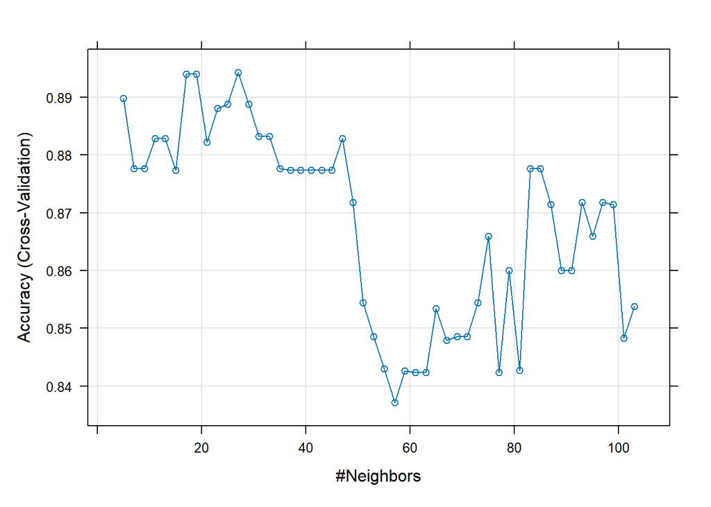

```r
plot(knn.fit)
```

The ROC curve can be plotted. knn.fit automatically takes the value of k which generated the highest probability. So it is assumed that k = 27 when generating the following graph.

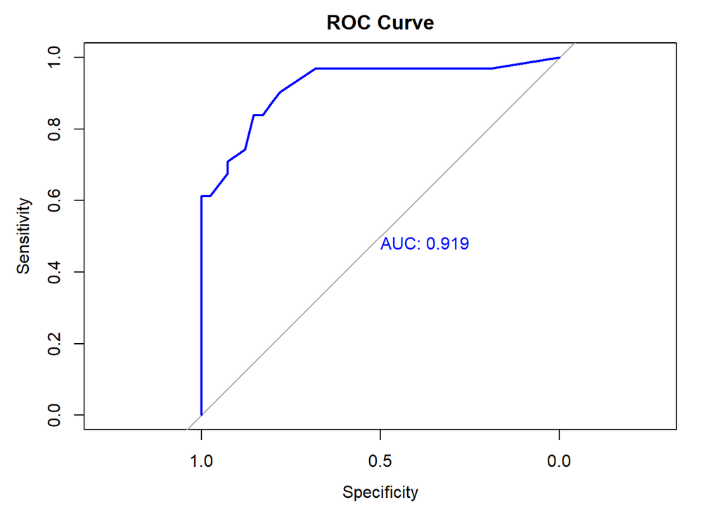

```r
#calculate probabilities
knn.prob = predict(knn.fit,uns_testData,type="prob")

#plot ROC curve
roc_curve = suppressMessages(roc(uns_testData$Classes, knn.prob[,2]))
plot(roc_curve, col = "blue", main = "ROC Curve", print.auc = TRUE)
```

The AUC of this model when applied to the entirety of the dataset is 0.919. This is currently the lowest recorded AUC for this subset. This positively reinforces the idea that the dataset is not really suited for highly nonlinear models.

It would still be interesting to see if KNN could handle Wind Speed better than the previous models. The ROC curve is generated.

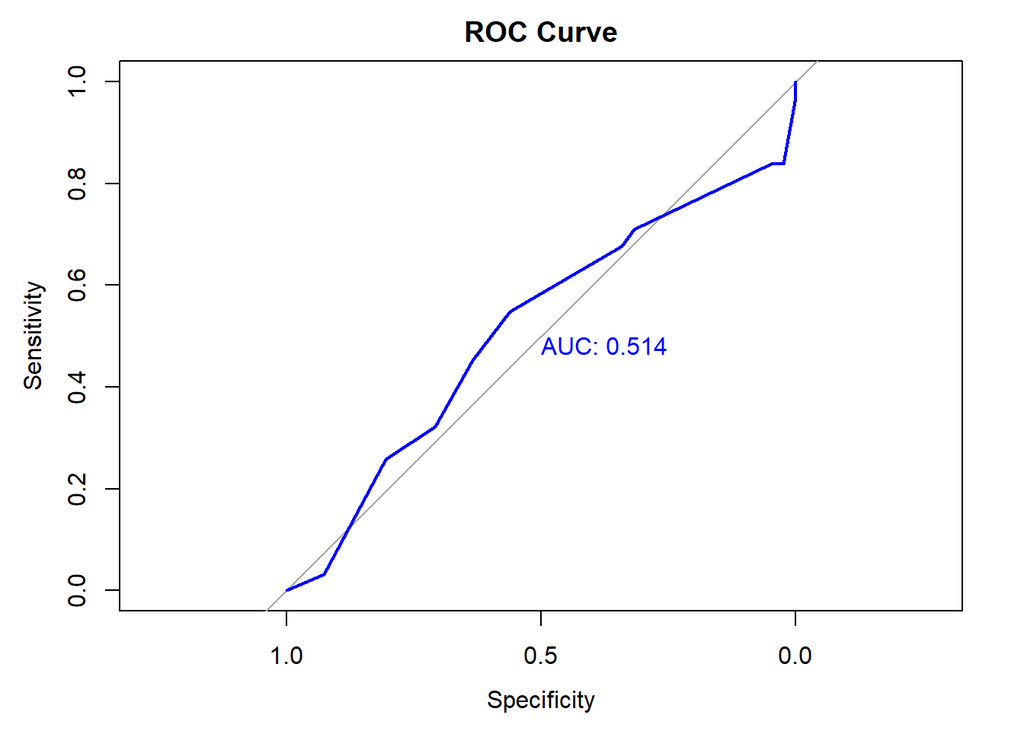

```r
#set the seed
set.seed(123)

#fit the model
knn.fit = train(Classes ~ Ws, data = uns_trainData, method="knn", tuneLength = 50, trControl = trainControl(method="cv", classProbs = TRUE))

#calculate probabilities
knn.prob = predict(knn.fit,uns_testData,type="prob")

#plot ROC curve
roc_curve = suppressMessages(roc(uns_testData$Classes, knn.prob[,2]))
plot(roc_curve, col = "blue", main = "ROC Curve", print.auc = TRUE)
```

The AUC for this ROC curve is actually lower than that of the one generated in QDA. This is an indication that KNN is simply too nonlinear to handle the data involved. While QDA may have improved the use of the predictor slightly, KNN was not able to discern an effective pattern.

### Multiple ROC Curve

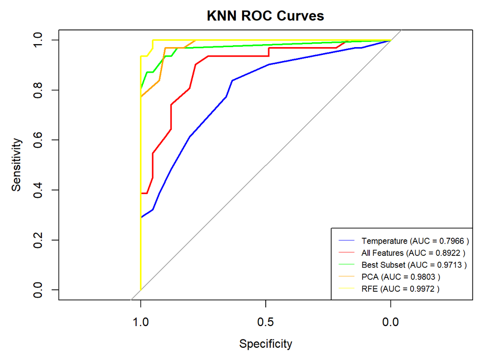

```r
#set the seed
set.seed(123)

#fit the models
knn.fit1 = train(Classes ~ Temperature, data = uns_trainData, method="knn", tuneLength = 50, trControl = trainControl(method="cv", classProbs = TRUE))
knn.fit2 = train(Classes ~ ., data = uns_trainData, method="knn", tuneLength = 50, trControl = trainControl(method="cv", classProbs = TRUE))
knn.fit3 = train(Classes ~ RH + FFMC + DMC + FWI, data = uns_trainData, method="knn", tuneLength = 50, trControl = trainControl(method="cv", classProbs = TRUE))
knn.fit4 = train(Classes ~ BUI + FFMC + DMC + DC, data = uns_trainData, method="knn", tuneLength = 50, trControl = trainControl(method="cv", classProbs = TRUE))
knn.fit5 = train(Classes ~ ISI + FFMC, data = uns_trainData, method="knn", tuneLength = 50, trControl = trainControl(method="cv", classProbs = TRUE))

#predict the values
knn.prob1 = predict(knn.fit1,uns_testData,type="prob")
knn.prob2 = predict(knn.fit2,uns_testData,type="prob")
knn.prob3 = predict(knn.fit3,uns_testData,type="prob")
knn.prob4 = predict(knn.fit4,uns_testData,type="prob")
knn.prob5 = predict(knn.fit5,uns_testData,type="prob")

#compute ROC curves
roc1 = suppressMessages(roc(uns_testData$Classes, knn.prob1[,2]))
roc2 = suppressMessages(roc(uns_testData$Classes, knn.prob2[,2]))
roc3 = suppressMessages(roc(uns_testData$Classes, knn.prob3[,2]))
roc4 = suppressMessages(roc(uns_testData$Classes, knn.prob4[,2]))
roc5 = suppressMessages(roc(uns_testData$Classes, knn.prob5[,2]))

#compute aucs
auc1 = auc(roc1)
auc2 = auc(roc2)
auc3 = auc(roc3)
auc4 = auc(roc4)
auc5 = auc(roc5)

#create a dataframe and store AUC to be used in comparison later
auc1.data = data.frame(
  Model = "KNN",
  Temperature = auc1,
  Entire_Dataset = auc2,
  Best_Subset = auc3,
  PCA = auc4,
  RFE = auc5
)

auc.data = rbind(auc.data,auc1.data)

#plot the first ROC curve
plot.roc(roc1, col = "blue", main = "KNN ROC Curves")

#add the rest of the curves as lines
lines.roc(roc2, col = "red", print.auc = TRUE, print.auc.y = 0.4)

lines.roc(roc3, col = "green", print.auc = TRUE, print.auc.y = 0.3)

lines.roc(roc4, col = "orange", print.auc = TRUE, print.auc.y = 0.2)

lines.roc(roc5, col = "yellow", print.auc = TRUE, print.auc.y = 0.1)

legend_labels = c(
  paste("Temperature (AUC =", round(auc1, 4), ")"),
  paste("All Features (AUC =", round(auc2, 4), ")"),
  paste("Best Subset (AUC =", round(auc3, 4), ")"),
  paste("PCA (AUC =", round(auc4, 4), ")"),
  paste("RFE (AUC =", round(auc5, 4), ")")
)

#legend
legend("bottomright", legend = legend_labels, col = c("blue", "red", "green", "orange", "yellow"), lwd = 0.5, cex = 0.7)
```

```r
knn_plot = recordPlot()
```

We see an overall decrease in all the AUCs except for temperature. The dataset is definitely better off with less flexible approaches.

### K Parameter Analysis

The accuracy of each model for different values of k can be plotted and analyzed.

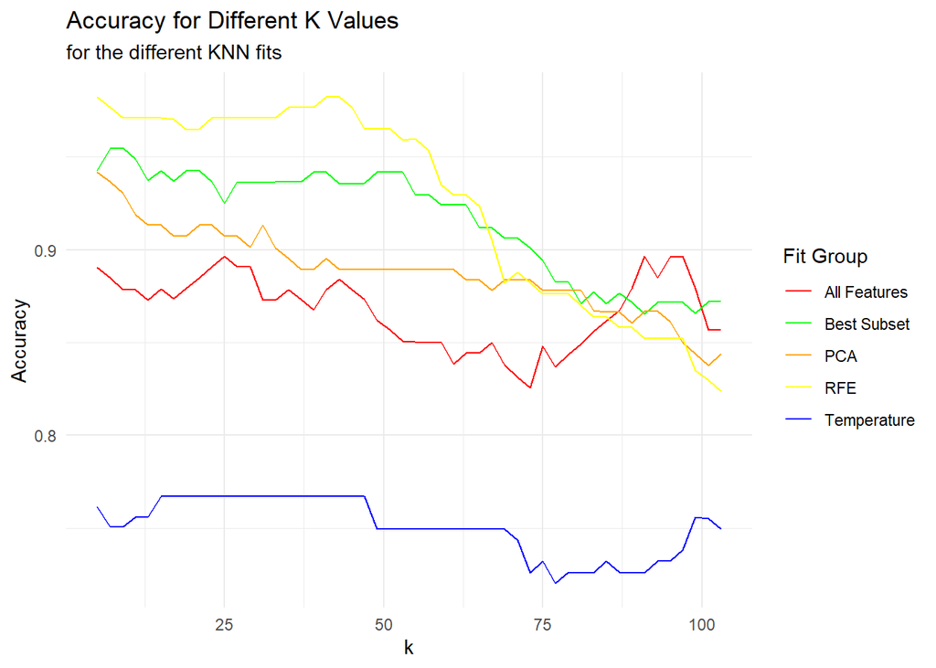

```r
#assign labels to each fit
knn.fit1$results$Group <- "Temperature"
knn.fit2$results$Group <- "All Features"
knn.fit3$results$Group <- "Best Subset"
knn.fit4$results$Group <- "PCA"
knn.fit5$results$Group <- "RFE"

#combine the results into a single data frame
combined_results <- bind_rows(knn.fit1$results, knn.fit2$results, knn.fit3$results, knn.fit4$results, knn.fit5$results)

#plot the fits
K <- ggplot(combined_results, aes(x = k, y = Accuracy, colour = Group)) +
      geom_line() +
      scale_colour_manual(values = c("Temperature" = "blue", "All Features" = "red", "Best Subset" = "green", "PCA" = "orange", "RFE" = "yellow")) +
      labs(title = "Accuracy for Different K Values", subtitle = "for the different KNN fits",colour = "Fit Group") +
      theme_minimal()

plot(K)
```

## Tree Methods

### Reverting Back to Unstandardized Data

The logic behind this step is that tree models are especially good at being interpretable. With standardized data we lose this interpretation of the coefficients and split points of the tree. For this reason, the dataset will be taken in its unstandardized form.

### Simple Classification Tree

Using the rpart library, a simple classification tree can be generated. This will be done taking all the predictors into account at first.

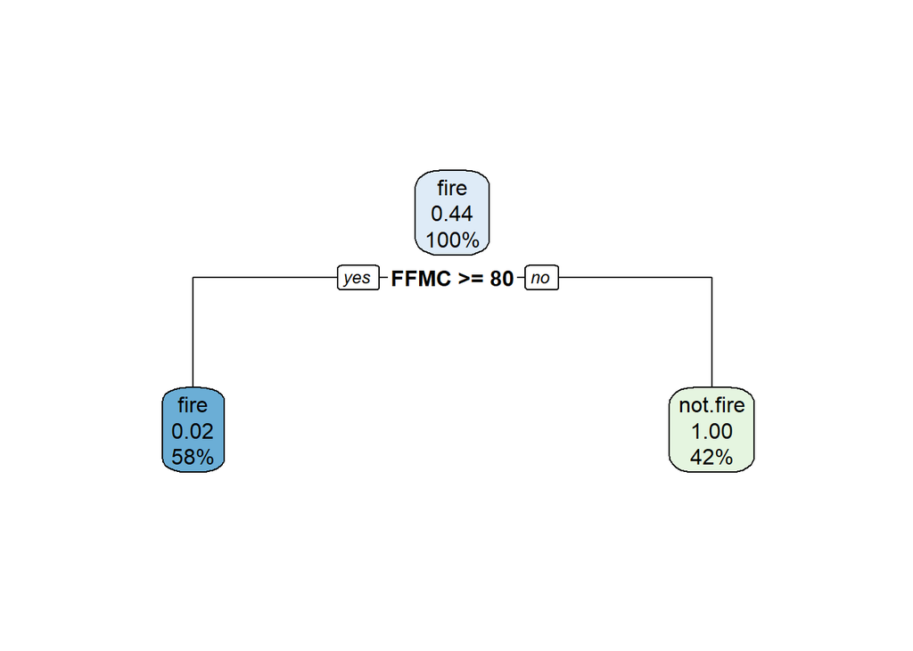

```r
classifier = rpart(Classes~.,data = uns_trainData, method = "class")
rpart.plot(classifier)
```

It seems that the algorithm has determined that the optimal tree depth is 1. The tree differentiates between the two classes based on FFMC only. If an entry has an FFMC greater than or equal to 80, it should be classified as a fire. Any less and the opposite should be predicted. We already know that FFMC is a strong predictor as it shows up in all three of the subsets generated by best subset selection, PCA and RFE. Based on this decision tree, FFMC is the most and only significant predictor.

Just to make sure that we have our classifier running properly, we fit the model to a subset comprising of Temperature paired with BUI.

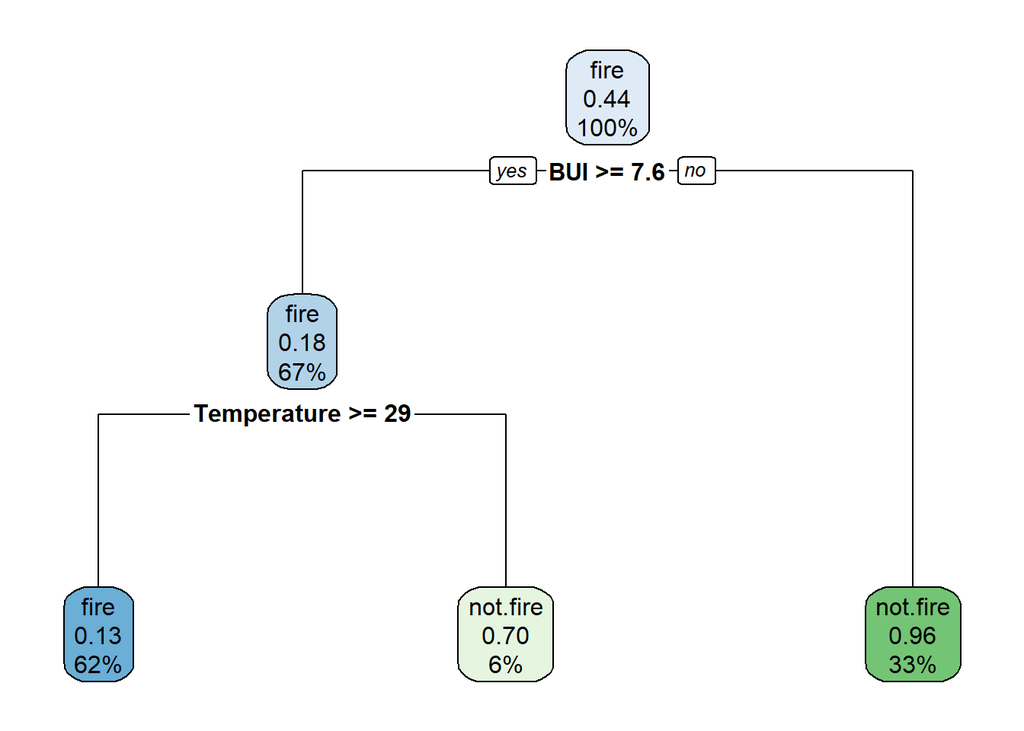

```r
classifier1 = rpart(Classes~Temperature + BUI,data = uns_trainData, method = "class")
rpart.plot(classifier1)
```

This combination generates a more intricate plot. However, at this point, we are fairly confident that the two predictors chosen will not offer the best overall performance. Therefore, we stick to our original subsets and explain the simplistic phenomenon as a result of the separability of classes. We know from previous analysis and modelling that the data is highly linearly separable. Therefore a tree with a depth of 1 may have no trouble picking up on this distinction.

```r
#predicting the test set results
y_pred = predict(classifier,
                 newdata = uns_testData,
                 type = 'class')

#generate a confusion matrix
table(uns_testY,y_pred)
```

```
##           y_pred
## uns_testY  fire not.fire
##   fire       41        0
##   not fire    2       29
```

Without needing to calculate, accuracy, precision and recall are all fairly high. However, the predictor is not perfect and still generates two false positives

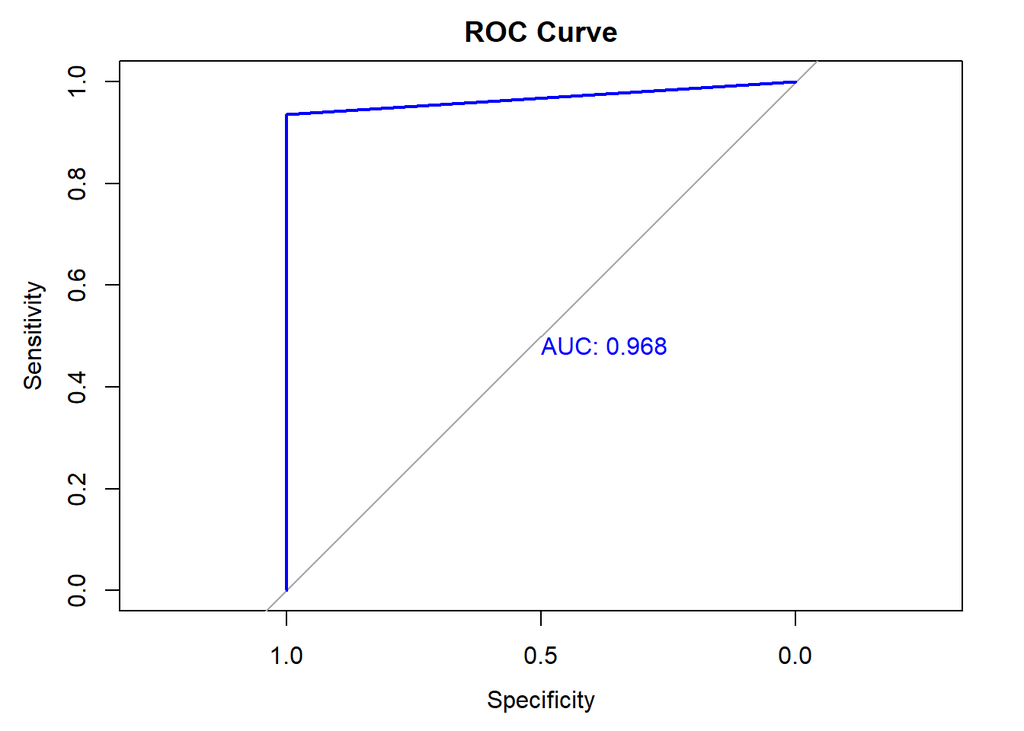

```r
#predicting the test set to be outputted as probabilities rather than classes
y_pred = predict(classifier,
                 newdata = uns_testData,
                 type = 'prob')

#plotting the ROC curve
roc_curve = suppressMessages(roc(uns_testY, y_pred[,2]))
plot(roc_curve, col = "blue", main = "ROC Curve", print.auc = TRUE)
```

The AUC is relatively high reaffirming the accuracy of the simplistic decision tree.

### Multiple ROC Curve

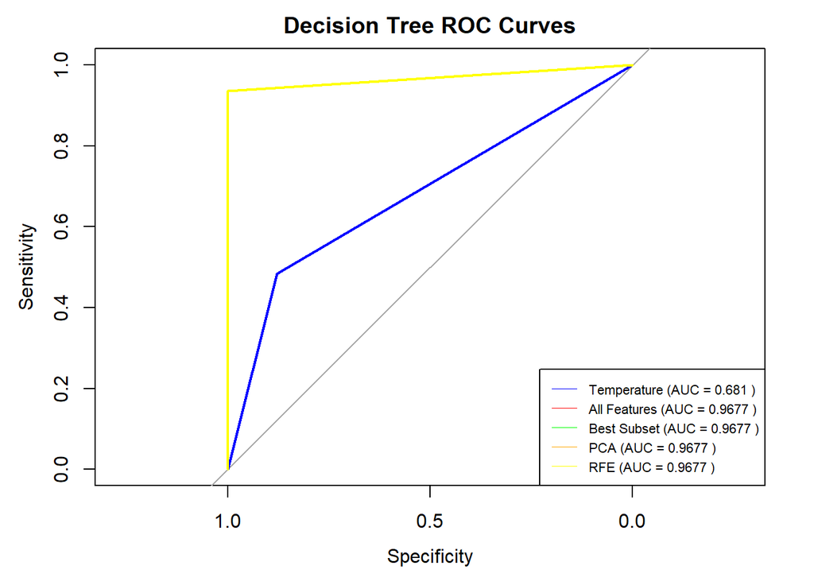

```r
#set the seed
set.seed(123)

#fit the models
classifier1 = rpart(Classes~Temperature,data = uns_trainData, method = "class")
classifier2 = rpart(Classes~.,data = uns_trainData, method = "class")
classifier3 = rpart(Classes~FWI + DMC + RH + FFMC,data = uns_trainData, method = "class")
classifier4 = rpart(Classes~BUI+DMC+FFMC+DC,data = uns_trainData, method = "class")
classifier5 = rpart(Classes~ISI+FFMC,data = uns_trainData, method = "class")

#predict the values
y_pred1 = predict(classifier1, newdata = uns_testData, type = 'prob')
y_pred2 = predict(classifier2, newdata = uns_testData, type = 'prob')
y_pred3 = predict(classifier3, newdata = uns_testData, type = 'prob')
y_pred4 = predict(classifier4, newdata = uns_testData, type = 'prob')
y_pred5 = predict(classifier5, newdata = uns_testData, type = 'prob')

#compute ROC curves
roc1 = suppressMessages(roc(uns_testY, y_pred1[,2]))
roc2 = suppressMessages(roc(uns_testY, y_pred2[,2]))
roc3 = suppressMessages(roc(uns_testY, y_pred3[,2]))
roc4 = suppressMessages(roc(uns_testY, y_pred4[,2]))
roc5 = suppressMessages(roc(uns_testY, y_pred5[,2]))

#compute aucs
auc1 = auc(roc1)
auc2 = auc(roc2)
auc3 = auc(roc3)
auc4 = auc(roc4)
auc5 = auc(roc5)

#create a dataframe and store AUC to be used in comparison later
auc1.data = data.frame(
  Model = "Decision Tree",
  Temperature = auc1,
  Entire_Dataset = auc2,
  Best_Subset = auc3,
  PCA = auc4,
  RFE = auc5
)

auc.data = rbind(auc.data,auc1.data)

#plot the first ROC curve
plot.roc(roc1, col = "blue", main = "Decision Tree ROC Curves")

#add the rest of the curves as lines
lines.roc(roc2, col = "red", print.auc = TRUE, print.auc.y = 0.4)

lines.roc(roc3, col = "green", print.auc = TRUE, print.auc.y = 0.3)

lines.roc(roc4, col = "orange", print.auc = TRUE, print.auc.y = 0.2)

lines.roc(roc5, col = "yellow", print.auc = TRUE, print.auc.y = 0.1)

legend_labels = c(
  paste("Temperature (AUC =", round(auc1, 4), ")"),
  paste("All Features (AUC =", round(auc2, 4), ")"),
  paste("Best Subset (AUC =", round(auc3, 4), ")"),
  paste("PCA (AUC =", round(auc4, 4), ")"),
  paste("RFE (AUC =", round(auc5, 4), ")")
)

#legend
legend("bottomright", legend = legend_labels, col = c("blue", "red", "green", "orange", "yellow"), lwd = 0.5, cex = 0.7)
```

```r
tree_plot = recordPlot()
```

All the AUCs and ROC curves for the subsets excluding Temperature are the same. This implies that the decision trees for each of these fits are the same and the same classification was made based on FFMC. When FFMC is omitted, the model is forced to make a different assumption resulting in a lower AUC.

### Pruning

Obviously since the model has determined a tree of depth = 1 to be optimal, there is no need for pruning let alone room for it.

### Bagging

We begin by fitting the data. 50 bags will be chosen i.e 50 models will be trained. out-of-bag error is included meaning that excluded entries from each run are used to estimate the model’s performance similar to cross validation. The minimum number of observations that must exist in a node for a split to be attempted is set to 2. Finally, cp is set to 0 meaning that the algorithm will attempt to grow the tree to its maximum size and then prune it.

There is little need to tune these hyperparameters. This was done anyways in testing and showed that increasing the number of bags or playing with the complexity didn’t change the output. This may be explained by the simplistic nature of the data and the lack of need for decision tree splits.

```r
set.seed(123)

#fit the bagged model
bag = bagging(
  formula = Classes ~ .,
  data = uns_trainData,
  nbagg = 50,
  coob = TRUE,
  control = rpart.control(minsplit = 2, cp = 0,
                         min_depth=2)
)

#predicting the test set results
y_pred = predict(bag, uns_testX, type = 'class')

#generate a confusion matrix
table(uns_testY,y_pred$class)
```

```
##
## uns_testY  fire not.fire
##   fire       41        0
##   not fire    2       29
```

We see there is no change in the output between the simple decision tree and the one implementing bagging. However, we must analyze some of the trees before making a definitive analysis.

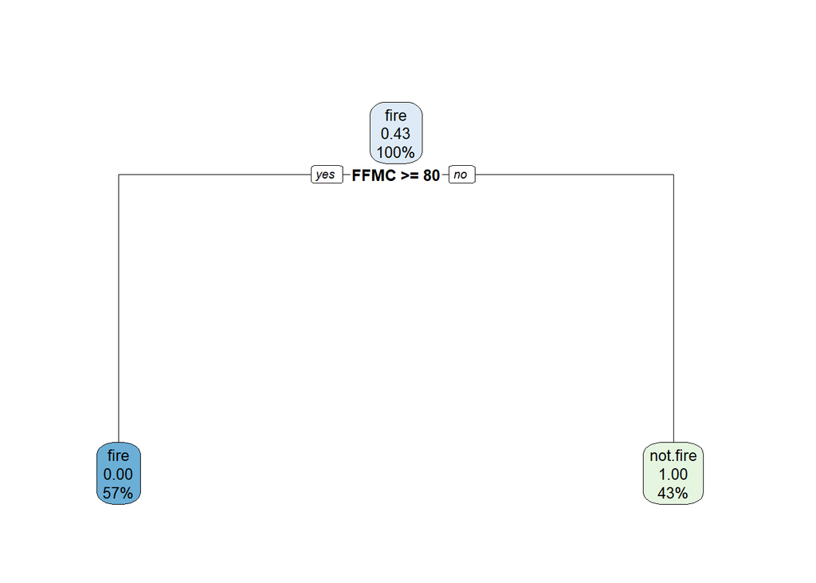

```r
A = suppressWarnings(rpart.plot(bag$trees[[3]], cex = 0.8, box.palette = "auto"))
```

The decision tree shown above is generated from the third bag. In fact many of the bags generate this exact tree. This is the simple decision tree shown in the beginning of this section. However, some bags offer different results.

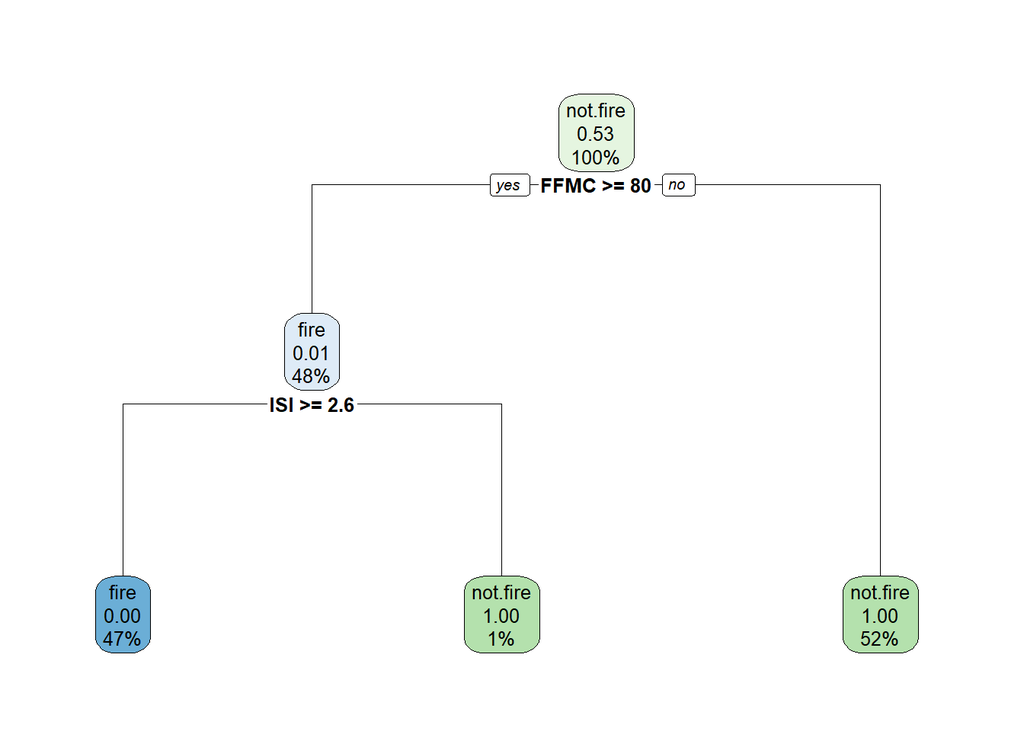

```r
suppressWarnings(rpart.plot(bag$trees[[5]], cex = 0.8, box.palette = "auto"))
```

The decision tree shown above is generated from the 5th bag. We note that now, 1 extra value is marked as “not fire” after making a split based on ISI. These two predictors are the exact predictors that were provided by RFE early on in the feature selection section.

The ROC curve is generated as follows.

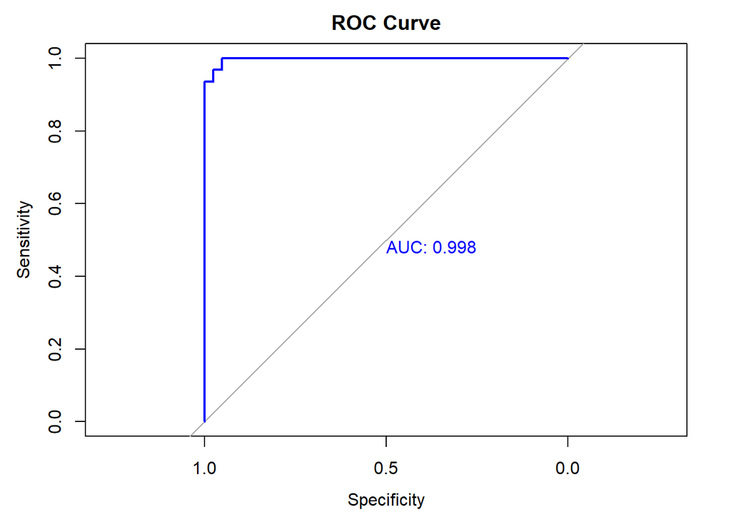

```r
#predicting the test set to be outputted as probabilities rather than classes
y_pred = predict(bag,
                 uns_testX,
                 type = 'prob')
#plotting the ROC curve
roc_curve = suppressMessages(roc(uns_testY, y_pred$votes[,2]))
plot(roc_curve, col = "blue", main = "ROC Curve", print.auc = TRUE)
```

The AUC has actually improved a little due to the presence of slightly more intricate trees.

### Multiple ROC Curve

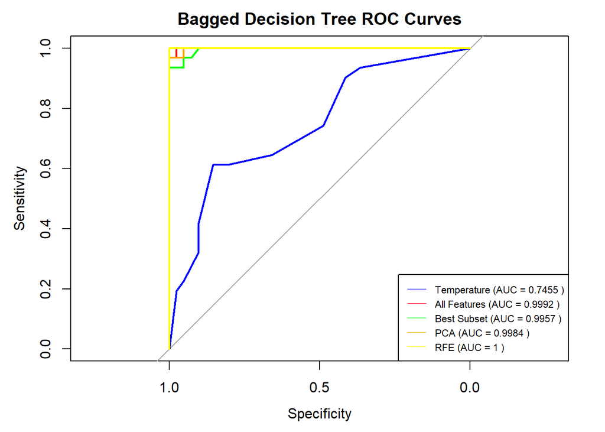

```r
#set the seed
set.seed(123)

#fit the models
bag1 = bagging(formula = Classes ~ Temperature, data = trainData, nbagg = 50,    coob = TRUE, control = rpart.control(minsplit = 2, cp = 0, min_depth=2))
bag2 = bagging(formula = Classes ~ ., data = trainData, nbagg = 50,    coob = TRUE, control = rpart.control(minsplit = 2, cp = 0, min_depth=2))
bag3 = bagging(formula = Classes ~ FWI + DMC + RH + FFMC, data = trainData, nbagg = 50,    coob = TRUE, control = rpart.control(minsplit = 2, cp = 0, min_depth=2))
bag4 = bagging(formula = Classes ~ BUI+DMC+FFMC+DC, data = trainData, nbagg = 50,    coob = TRUE, control = rpart.control(minsplit = 2, cp = 0, min_depth=2))
bag5 = bagging(formula = Classes ~ ISI+FFMC, data = trainData, nbagg = 50,    coob = TRUE, control = rpart.control(minsplit = 2, cp = 0, min_depth=2))

#predict the values
y_pred1 = predict(bag1, testData, type = 'prob')
y_pred2 = predict(bag2, testData, type = 'prob')
y_pred3 = predict(bag3, testData, type = 'prob')
y_pred4 = predict(bag4, testData, type = 'prob')
y_pred5 = predict(bag5, testData, type = 'prob')

#compute ROC curves
roc1 = suppressMessages(roc(testY, y_pred1$votes[,2]))
roc2 = suppressMessages(roc(testY, y_pred2$votes[,2]))
roc3 = suppressMessages(roc(testY, y_pred3$votes[,2]))
roc4 = suppressMessages(roc(testY, y_pred4$votes[,2]))
roc5 = suppressMessages(roc(testY, y_pred5$votes[,2]))

#compute aucs
auc1 = auc(roc1)
auc2 = auc(roc2)
auc3 = auc(roc3)
auc4 = auc(roc4)
auc5 = auc(roc5)

#create a dataframe and store AUC to be used in comparison later
auc1.data = data.frame(
  Model = "Bagged Decision Tree",
  Temperature = auc1,
  Entire_Dataset = auc2,
  Best_Subset = auc3,
  PCA = auc4,
  RFE = auc5
)

auc.data = rbind(auc.data,auc1.data)

#plot the first ROC curve
plot.roc(roc1, col = "blue", main = "Bagged Decision Tree ROC Curves")

#add the rest of the curves as lines
lines.roc(roc2, col = "red", print.auc = TRUE, print.auc.y = 0.4)

lines.roc(roc3, col = "green", print.auc = TRUE, print.auc.y = 0.3)

lines.roc(roc4, col = "orange", print.auc = TRUE, print.auc.y = 0.2)

lines.roc(roc5, col = "yellow", print.auc = TRUE, print.auc.y = 0.1)

legend_labels = c(
  paste("Temperature (AUC =", round(auc1, 4), ")"),
  paste("All Features (AUC =", round(auc2, 4), ")"),
  paste("Best Subset (AUC =", round(auc3, 4), ")"),
  paste("PCA (AUC =", round(auc4, 4), ")"),
  paste("RFE (AUC =", round(auc5, 4), ")")
)

#legend
legend("bottomright", legend = legend_labels, col = c("blue", "red", "green", "orange", "yellow"), lwd = 0.5, cex = 0.7)
```

```r
bag_plot = recordPlot()
```

There is definitely more variability when considering each of the chosen subsets. This has resulted in an overall increase in AUC. We note that the AUC for the RFE subset is equal to 1. This makes sense as the best decision trees obtained were the ones that combined these two predictors in the decision making.

### Random Forest

In addition to choosing random assortments of entries, random assortments of predictors can be chosen as well. In fact this was already conducted in feature selection. RFE was paired with this method in order to determine the factors that carried the most weight within the dataset. Those two factors turned out to be ISI and FFMC. And seeing as that result is consistent with the results from Bagging, it is unlikely that there is much more improvement left for Random Forest to carry out. Regardless, the confusion matrix is generated as follows.

```r
forest = randomForest(Classes~., data = uns_trainData, ntree = 500)
y_pred = predict(forest,uns_testX)
table(uns_testY, y_pred)
```

```
##           y_pred
## uns_testY  fire not.fire
##   fire       40        1
##   not fire    2       29
```

### Multiple ROC Curve

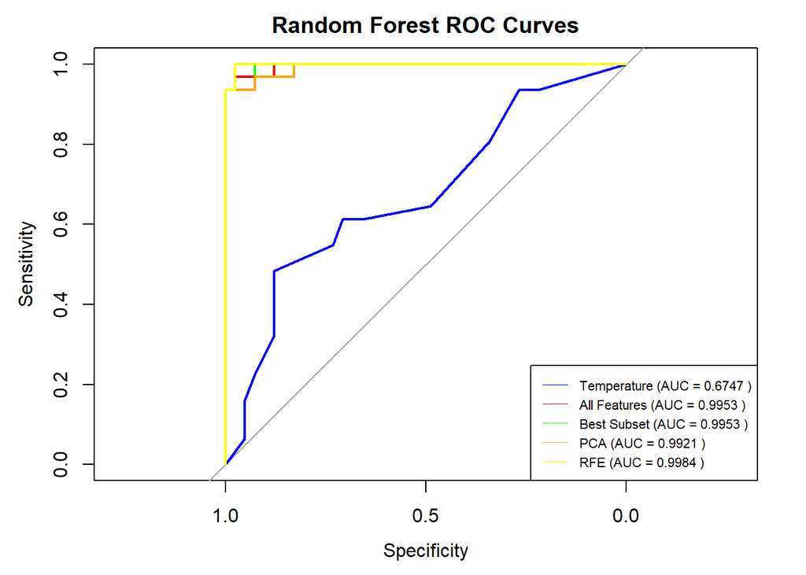

```r
#set the seed
set.seed(123)

#fit the models
forest1 = randomForest(Classes~Temperature, data = uns_trainData, ntree = 500)
forest2 = randomForest(Classes~., data = uns_trainData, ntree = 500)
forest3 = randomForest(Classes~RH+DMC+FFMC+FWI, data = uns_trainData, ntree = 500)
forest4 = randomForest(Classes~BUI+FFMC+DMC+DC, data = uns_trainData, ntree = 500)
forest5 = randomForest(Classes~ISI+FFMC, data = uns_trainData, ntree = 500)

#predict the values
y_pred1 = predict(forest1, newdata = uns_testData, type = 'prob')
y_pred2 = predict(forest2, newdata = uns_testData, type = 'prob')
y_pred3 = predict(forest3, newdata = uns_testData, type = 'prob')
y_pred4 = predict(forest4, newdata = uns_testData, type = 'prob')
y_pred5 = predict(forest5, newdata = uns_testData, type = 'prob')

#compute ROC curves
roc1 = suppressMessages(roc(uns_testY, y_pred1[,2]))
roc2 = suppressMessages(roc(uns_testY, y_pred2[,2]))
roc3 = suppressMessages(roc(uns_testY, y_pred3[,2]))
roc4 = suppressMessages(roc(uns_testY, y_pred4[,2]))
roc5 = suppressMessages(roc(uns_testY, y_pred5[,2]))

#compute aucs
auc1 = auc(roc1)
auc2 = auc(roc2)
auc3 = auc(roc3)
auc4 = auc(roc4)
auc5 = auc(roc5)

#create a dataframe and store AUC to be used in comparison later
auc1.data = data.frame(
  Model = "Random Forest",
  Temperature = auc1,
  Entire_Dataset = auc2,
  Best_Subset = auc3,
  PCA = auc4,
  RFE = auc5
)

auc.data = rbind(auc.data,auc1.data)

#plot the first ROC curve
plot.roc(roc1, col = "blue", main = "Random Forest ROC Curves")

#add the rest of the curves as lines
lines.roc(roc2, col = "red", print.auc = TRUE, print.auc.y = 0.4)

lines.roc(roc3, col = "green", print.auc = TRUE, print.auc.y = 0.3)

lines.roc(roc4, col = "orange", print.auc = TRUE, print.auc.y = 0.2)

lines.roc(roc5, col = "yellow", print.auc = TRUE, print.auc.y = 0.1)

legend_labels = c(
  paste("Temperature (AUC =", round(auc1, 4), ")"),
  paste("All Features (AUC =", round(auc2, 4), ")"),
  paste("Best Subset (AUC =", round(auc3, 4), ")"),
  paste("PCA (AUC =", round(auc4, 4), ")"),
  paste("RFE (AUC =", round(auc5, 4), ")")
)

#legend
legend("bottomright", legend = legend_labels, col = c("blue", "red", "green", "orange", "yellow"), lwd = 0.5, cex = 0.7)
```

```r
rf_plot = recordPlot()
```

There is a slight decrease in the AUC of the RFE fit. This makes sense as random forest was taking subsets of these two predictors rather than allowing them to completely coexist. However, all the AUCs are generally high.

### Boosting

The final method of creating decision trees is Boosting. Here, trees are developed sequentially with weight being added to elements that are missclassified each step. The parameter mfinal denotes the number of trees to make. 100 is chosen and should be sufficient for the size of the data at hand. (In private testing, increasing this parameter did not change the results). A cp of 0 is chosen allowing for trees to grow as deep as possible and a minsplit of 2 allows for groups to contain single elements.

```r
set.seed(123)

model = boosting(Classes ~ ., data = uns_trainData, boos = TRUE, mfinal = 100, control = rpart.control(cp = 0, minsplit = 2))

# Make predictions on the test set
predictions = predict(model, uns_testX)

# Calculate the confusion matrix
table(uns_testY,predictions$class)
```

```
##
## uns_testY  fire not.fire
##   fire       41        0
##   not fire    2       29
```

### Multiple ROC Curve

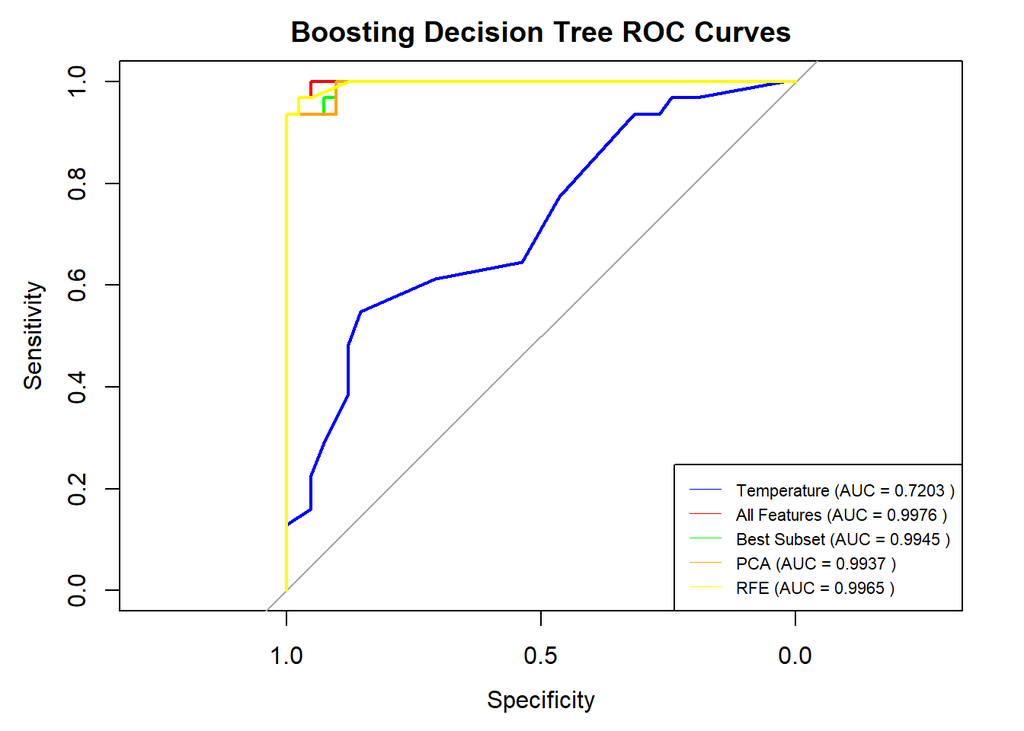

```r
#set the seed
set.seed(123)

#fit the models
boost1 = boosting(Classes ~ Temperature, data = uns_trainData, boos = TRUE, mfinal = 100, control = rpart.control(cp = 0.01, minsplit = 2))
boost2 = boosting(Classes ~ ., data = uns_trainData, boos = TRUE, mfinal = 100, control = rpart.control(cp = 0.01, minsplit = 2))
boost3 = boosting(Classes ~ FWI + DMC + FFMC + RH, data = uns_trainData, boos = TRUE, mfinal = 100, control = rpart.control(cp = 0.01, minsplit = 2))
boost4 = boosting(Classes ~ BUI + FFMC + DMC + DC, data = uns_trainData, boos = TRUE, mfinal = 100, control = rpart.control(cp = 0.01, minsplit = 2))
boost5 = boosting(Classes ~ ISI + FFMC, data = uns_trainData, boos = TRUE, mfinal = 100, control = rpart.control(cp = 0.01, minsplit = 2))

#predict the values
y_pred1 = predict(boost1, newdata = uns_testData, type = 'prob')
y_pred2 = predict(boost2, newdata = uns_testData, type = 'prob')
y_pred3 = predict(boost3, newdata = uns_testData, type = 'prob')
y_pred4 = predict(boost4, newdata = uns_testData, type = 'prob')
y_pred5 = predict(boost5, newdata = uns_testData, type = 'prob')

#compute ROC curves
roc1 = suppressMessages(roc(uns_testY, y_pred1$prob[,2]))
roc2 = suppressMessages(roc(uns_testY, y_pred2$prob[,2]))
roc3 = suppressMessages(roc(uns_testY, y_pred3$prob[,2]))
roc4 = suppressMessages(roc(uns_testY, y_pred4$prob[,2]))
roc5 = suppressMessages(roc(uns_testY, y_pred5$prob[,2]))

#compute aucs
auc1 = auc(roc1)
auc2 = auc(roc2)
auc3 = auc(roc3)
auc4 = auc(roc4)
auc5 = auc(roc5)

#create a dataframe and store AUC to be used in comparison later
auc1.data = data.frame(
  Model = "boosted decision tree",
  Temperature = auc1,
  Entire_Dataset = auc2,
  Best_Subset = auc3,
  PCA = auc4,
  RFE = auc5
)

auc.data = rbind(auc.data,auc1.data)

#plot the first ROC curve
plot.roc(roc1, col = "blue", main = "Boosting Decision Tree ROC Curves")

#add the rest of the curves as lines
lines.roc(roc2, col = "red", print.auc = TRUE, print.auc.y = 0.4)

lines.roc(roc3, col = "green", print.auc = TRUE, print.auc.y = 0.3)

lines.roc(roc4, col = "orange", print.auc = TRUE, print.auc.y = 0.2)

lines.roc(roc5, col = "yellow", print.auc = TRUE, print.auc.y = 0.1)

legend_labels = c(
  paste("Temperature (AUC =", round(auc1, 4), ")"),
  paste("All Features (AUC =", round(auc2, 4), ")"),
  paste("Best Subset (AUC =", round(auc3, 4), ")"),
  paste("PCA (AUC =", round(auc4, 4), ")"),
  paste("RFE (AUC =", round(auc5, 4), ")")
)

#legend
legend("bottomright", legend = legend_labels, col = c("blue", "red", "green", "orange", "yellow"), lwd = 0.5, cex = 0.7)
```

```r
boost_plot = recordPlot()
```

Once again, results are very similar to the other decision tree algorithms. There is not much room left to improve and these methods have shown to fit the dataset really well on the whole.

## Support Vector Machine (SVM)

```r
levels(trainData$Classes) = make.names(levels(trainData$Classes))
```

The final model to be discussed in the project is SVM. Using all of the information gathered about the dataset so far, a linear kernel should have no problem classifying the data. To illustrate this the hyperplane can be plotted for the SVM between ISI and FFMC.

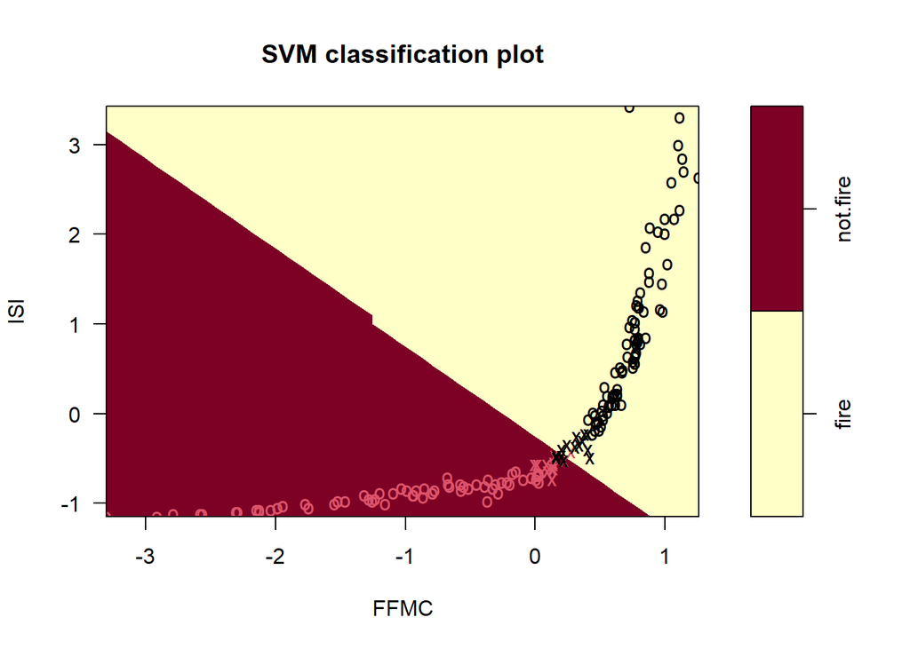

```r
svmfit = svm(Classes ~ ISI + FFMC, data = trainData, kernel = "linear")

plot(svmfit, cbind(trainData[5],trainData[8],trainData[11]))
```

We see that while the method may misclassify one or two data points, it does a very good job of separating the two classes.

However, it would be unfair to completely write off other kernels. Additionally, there is also a need to determine the optimal hyperparameters.

### Linear Kernel

Without tuning, the linear kernel outputs the following confusion matrix.

```r
svmfit = svm(Classes ~ ., data = trainData, kernel = "linear", probability = TRUE)
svm_pred = predict(svmfit,testX, probability = TRUE)
table(svm_pred,testY)
```

```
##           testY
## svm_pred   fire not fire
##   fire       40        2
##   not.fire    1       29
```

There is an accuracy of roughly 96%. And while this alone is not enough to determine the true predictive power of this specific model, we are less interested in this than we are in the potential for better results after hyperparameter tuning.

#### Hyperparameter Tuning

For a linear Kernel, the primary hyperparameter is C. This is the parameter that controls the trade-off between low training error and low testing error. In order to tune it, a range from 0.1 to 100 is tested and the best cost is outputted.

```r
tune.fit = tune.svm(Classes ~ ., data = trainData, type = "C-classification", kernel = "linear", cost = 10^(-1:2))

tune.fit$best.model
```

```
##
## Call:
## best.svm(x = Classes ~ ., data = trainData, cost = 10^(-1:2), type = "C-classification",
##     kernel = "linear")
##
##
## Parameters:
##    SVM-Type:  C-classification
##  SVM-Kernel:  linear
##        cost:  1
##
## Number of Support Vectors:  27
```

According to the above, the best value of C is 1. This is the default value used. With this knowledge the best achievable results with the linear kernel are the ones shown above.

Without calculating metrics, the linear kernel has performed well and classifies with fair accuracy. To the determine the extent however, the multiple ROC curve is drawn.

#### Multiple ROC Curve

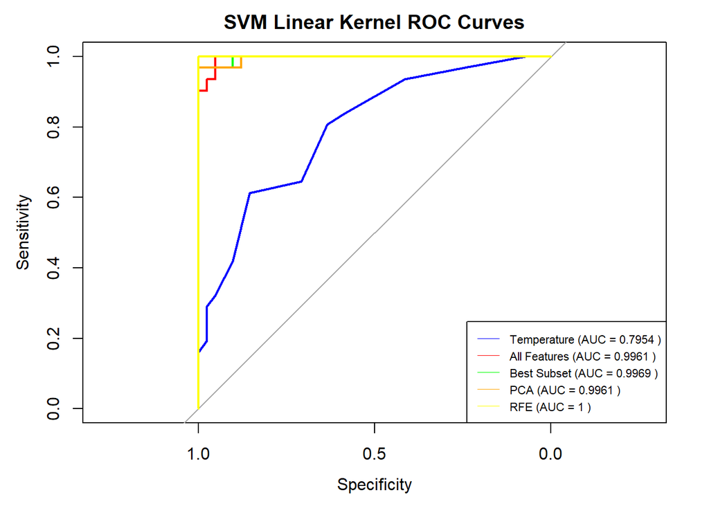

```r
#set the seed
set.seed(123)

#fit the models
svmfit1 = svm(Classes ~ Temperature, data = trainData, kernel = "linear", cost = 1, probability = TRUE)
svmfit2 = svm(Classes ~ ., data = trainData, kernel = "linear", cost = 1, probability = TRUE)
svmfit3 = svm(Classes ~ FWI + FFMC + DMC + RH, data = trainData, kernel = "linear", cost = 1, probability = TRUE)
svmfit4 = svm(Classes ~ BUI + FFMC + DMC + DC, data = trainData, kernel = "linear", cost = 1, probability = TRUE)
svmfit5 = svm(Classes ~ ISI + FFMC, data = trainData, kernel = "linear", cost = 1, probability = TRUE)

#predict the values
y_pred1 = predict(svmfit1, testX, type = "prob", probability = TRUE)
y_pred2 = predict(svmfit2, testX, type = 'prob', probability = TRUE)
y_pred3 = predict(svmfit3, testX, type = 'prob', probability = TRUE)
y_pred4 = predict(svmfit4, testX, type = 'prob', probability = TRUE)
y_pred5 = predict(svmfit5, testX, type = 'prob', probability = TRUE)

#compute ROC curves
roc1 = suppressMessages(roc(testY, attr(y_pred1, "probabilities")[,2]))
roc2 = suppressMessages(roc(testY, attr(y_pred2, "probabilities")[,2]))
roc3 = suppressMessages(roc(testY, attr(y_pred3, "probabilities")[,2]))
roc4 = suppressMessages(roc(testY, attr(y_pred4, "probabilities")[,2]))
roc5 = suppressMessages(roc(testY, attr(y_pred5, "probabilities")[,2]))

#compute aucs
auc1 = auc(roc1)
auc2 = auc(roc2)
auc3 = auc(roc3)
auc4 = auc(roc4)
auc5 = auc(roc5)

#create a dataframe and store AUC to be used in comparison later
auc1.data = data.frame(
  Model = "SVM (Linear Kernel)",
  Temperature = auc1,
  Entire_Dataset = auc2,
  Best_Subset = auc3,
  PCA = auc4,
  RFE = auc5
)

auc.data = rbind(auc.data,auc1.data)


#plot the first ROC curve
plot.roc(roc1, col = "blue", main = "SVM Linear Kernel ROC Curves")

#add the rest of the curves as lines
lines.roc(roc2, col = "red", print.auc = TRUE, print.auc.y = 0.4)

lines.roc(roc3, col = "green", print.auc = TRUE, print.auc.y = 0.3)

lines.roc(roc4, col = "orange", print.auc = TRUE, print.auc.y = 0.2)

lines.roc(roc5, col = "yellow", print.auc = TRUE, print.auc.y = 0.1)

legend_labels = c(
  paste("Temperature (AUC =", round(auc1, 4), ")"),
  paste("All Features (AUC =", round(auc2, 4), ")"),
  paste("Best Subset (AUC =", round(auc3, 4), ")"),
  paste("PCA (AUC =", round(auc4, 4), ")"),
  paste("RFE (AUC =", round(auc5, 4), ")")
)

#legend
legend("bottomright", legend = legend_labels, col = c("blue", "red", "green", "orange", "yellow"), lwd = 0.5, cex = 0.7)
```

```r
svm_lin = recordPlot()
```

The AUCs of each of the feature selected subsets are all almost equal to 1. As expected, the linear kernel does a good job of separating the classes.

### Polynomial Kernel

Without tuning, the polynomial kernel outputs the following confusion matrix

```r
svmfit = svm(Classes ~ ., data = trainData, kernel = "polynomial", degree = 2, probability = TRUE)
svm_pred = predict(svmfit,testX)
table(svm_pred,testY)
```

```
##           testY
## svm_pred   fire not fire
##   fire       41        6
##   not.fire    0       25
```

With an accuracy of 92%, this model is currently performing worse than the one with the linear kernel. In order to see if this can be changed, hyperparameters must be tuned.

#### Hyperparameter Tuning

In the case of a polynomial kernel, we are interested in a few more hyperparameters. In addition to C, we are now also curious about gamma. Gamma is a factor which basically controls the curvature of the decision boundary. We would also like to determine coef0, another value influencing the shape of the boundary. We do so in a similar way to the linear kernel approach. Gamma is given a choice between 0.1, 1 and 10 and the same applies for coef0.

```r
tune.fit = tune.svm(Classes ~ ., data = uns_trainData, type = "C-classification", kernel = "polynomial", degree = 2, cost = 10^(-1:2), gamma = c(0.1,1,10), coef0 = c(0.1,1,10))

tune.fit$best.parameters$cost
```

```
## [1] 10
```

```r
tune.fit$best.parameters$gamma
```

```
## [1] 0.1
```

```r
tune.fit$best.parameters$coef0
```

```
## [1] 10
```

For the polynomial kernel, a cost of 10, gamma of 0.1 and coef0 of 10 is preferred.

```r
svmfit = svm(Classes ~ ., data = trainData, kernel = "polynomial", gamma = 0.1, degree = 2, cost = 10, coef0 = 10, probability = TRUE)
svm_pred = predict(svmfit,testX)
table(svm_pred,testY)
```

```
##           testY
## svm_pred   fire not fire
##   fire       41        1
##   not.fire    0       30
```

Surprisingly, the polynomial kernel seems to have outperformed the linear kernel with an accuracy of 98.6%. The accuracy is not enough on its own, so the multiple ROC curve is shown.

#### Multiple ROC Curve

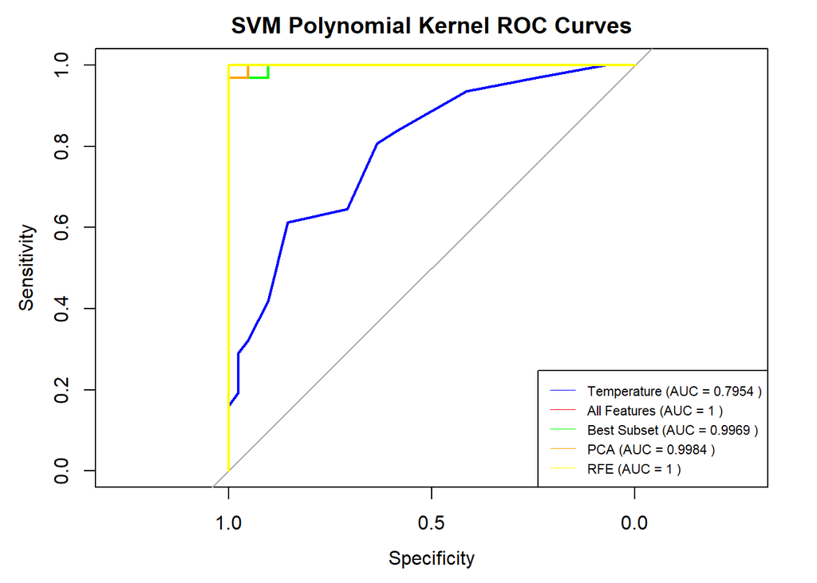

```r
#set the seed
set.seed(123)

#fit the models
svmfit1 = svm(Classes ~ Temperature, data = trainData, kernel = "polynomial", gamma = 0.1, degree = 2, cost = 10, coef0 = 10, probability = TRUE)
svmfit2 = svm(Classes ~ ., data = trainData, kernel = "polynomial", gamma = 0.1, degree = 2, cost = 10, coef0 = 10, probability = TRUE)
svmfit3 = svm(Classes ~ RH + FFMC + DMC + FWI, data = trainData, kernel = "polynomial", gamma = 0.1, degree = 2, cost = 10, coef0 = 10, probability = TRUE)
svmfit4 = svm(Classes ~ BUI + FFMC + DMC + DC, data = trainData, kernel = "polynomial", gamma = 0.1, degree = 2, cost = 10, coef0 = 10, probability = TRUE)
svmfit5 = svm(Classes ~ ISI + FFMC, data = trainData, kernel = "polynomial", gamma = 0.1, degree = 2, cost = 10, coef0 = 10, probability = TRUE)

#predict the values
y_pred1 = predict(svmfit1, testX, type = "prob", probability = TRUE)
y_pred2 = predict(svmfit2, testX, type = 'prob', probability = TRUE)
y_pred3 = predict(svmfit3, testX, type = 'prob', probability = TRUE)
y_pred4 = predict(svmfit4, testX, type = 'prob', probability = TRUE)
y_pred5 = predict(svmfit5, testX, type = 'prob', probability = TRUE)

#compute ROC curves
roc1 = suppressMessages(roc(testY, attr(y_pred1, "probabilities")[,2]))
roc2 = suppressMessages(roc(testY, attr(y_pred2, "probabilities")[,2]))
roc3 = suppressMessages(roc(testY, attr(y_pred3, "probabilities")[,2]))
roc4 = suppressMessages(roc(testY, attr(y_pred4, "probabilities")[,2]))
roc5 = suppressMessages(roc(testY, attr(y_pred5, "probabilities")[,2]))

#compute aucs
auc1 = auc(roc1)
auc2 = auc(roc2)
auc3 = auc(roc3)
auc4 = auc(roc4)
auc5 = auc(roc5)

#create a dataframe and store AUC to be used in comparison later
auc1.data = data.frame(
  Model = "SVM (Quadratic Kernel)",
  Temperature = auc1,
  Entire_Dataset = auc2,
  Best_Subset = auc3,
  PCA = auc4,
  RFE = auc5
)

auc.data = rbind(auc.data,auc1.data)

#plot the first ROC curve
plot.roc(roc1, col = "blue", main = "SVM Polynomial Kernel ROC Curves")

#add the rest of the curves as lines
lines.roc(roc2, col = "red")

lines.roc(roc3, col = "green")

lines.roc(roc4, col = "orange")

lines.roc(roc5, col = "yellow")

legend_labels = c(
  paste("Temperature (AUC =", round(auc1, 4), ")"),
  paste("All Features (AUC =", round(auc2, 4), ")"),
  paste("Best Subset (AUC =", round(auc3, 4), ")"),
  paste("PCA (AUC =", round(auc4, 4), ")"),
  paste("RFE (AUC =", round(auc5, 4), ")")
)

#legend
legend("bottomright", legend = legend_labels, col = c("blue", "red", "green", "orange", "yellow"), lwd = 0.5, cex = 0.7)
```

```r
svm_poly = recordPlot()
```

# Results Interpretation

The main metric used across all models to obtain a measure of performance was AUC. Confusion matrices were generated for each model but due to repetition and similarity, the computation of metrics such as accuracy, recall and precision were eventually omitted.

The multiple ROC curves generated throughout this project are all displayed below.

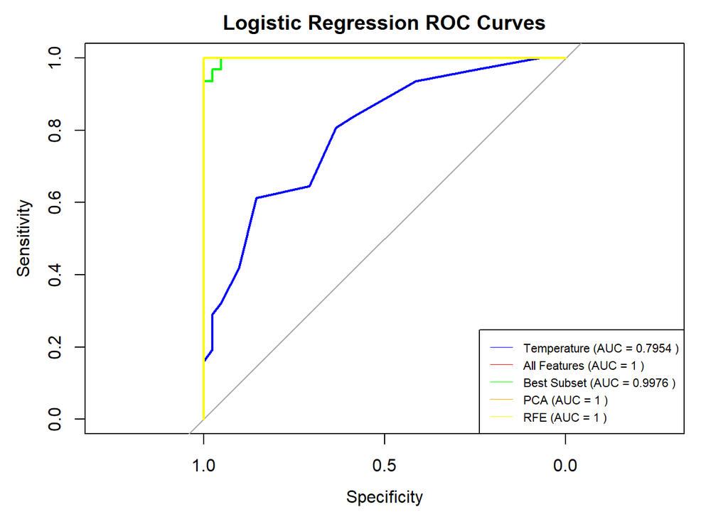

```r
plot_grid(lr_plot)
```

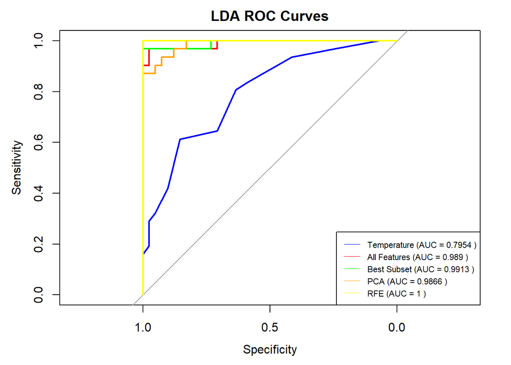

```r
plot_grid(lda_plot)
```

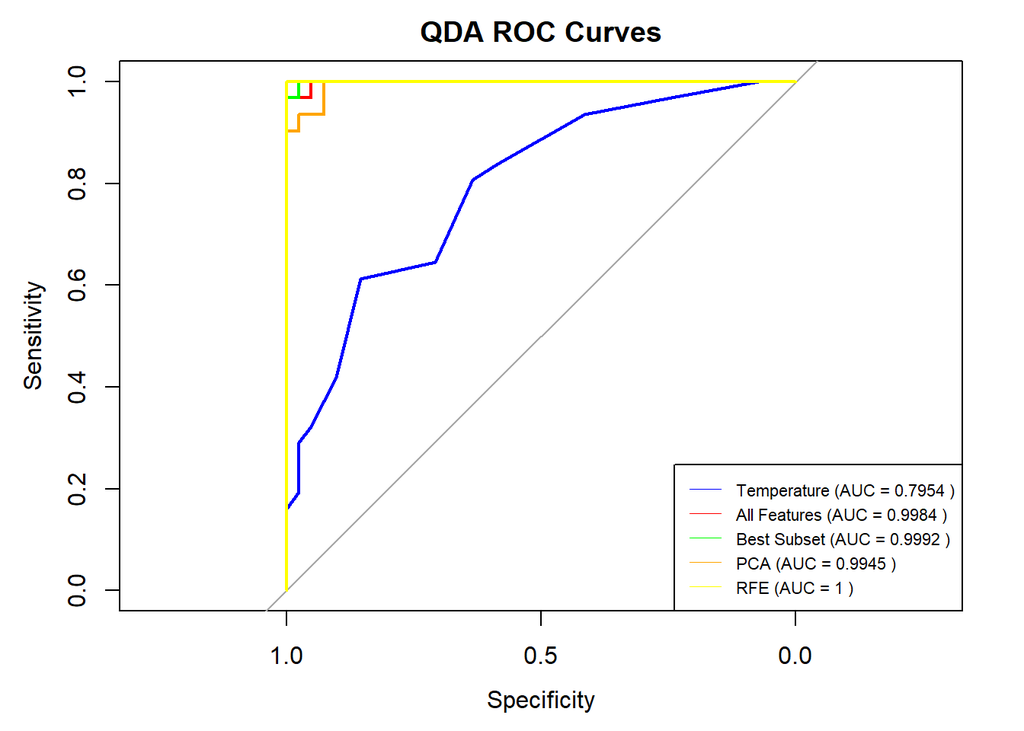

```r
plot_grid(qda_plot)
```

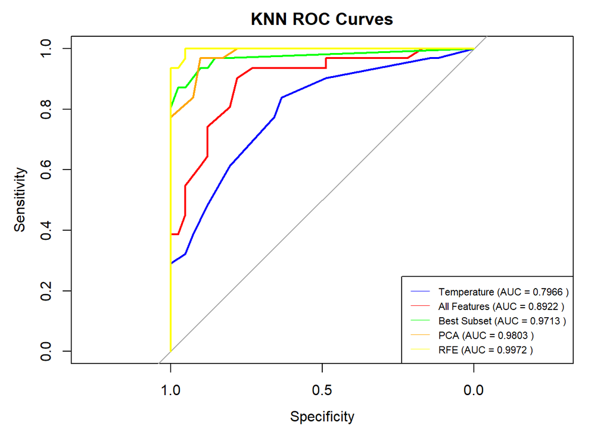

```r
plot_grid(knn_plot)
```

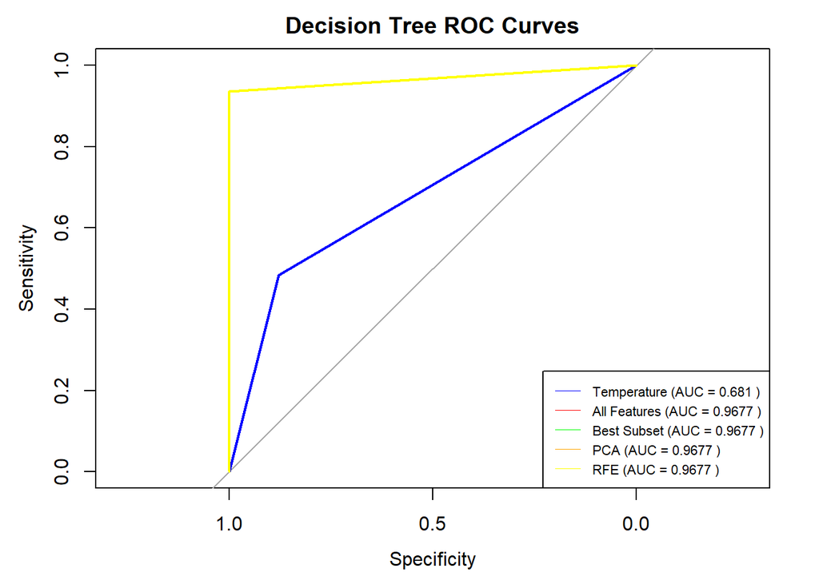

```r
plot_grid(tree_plot)
```

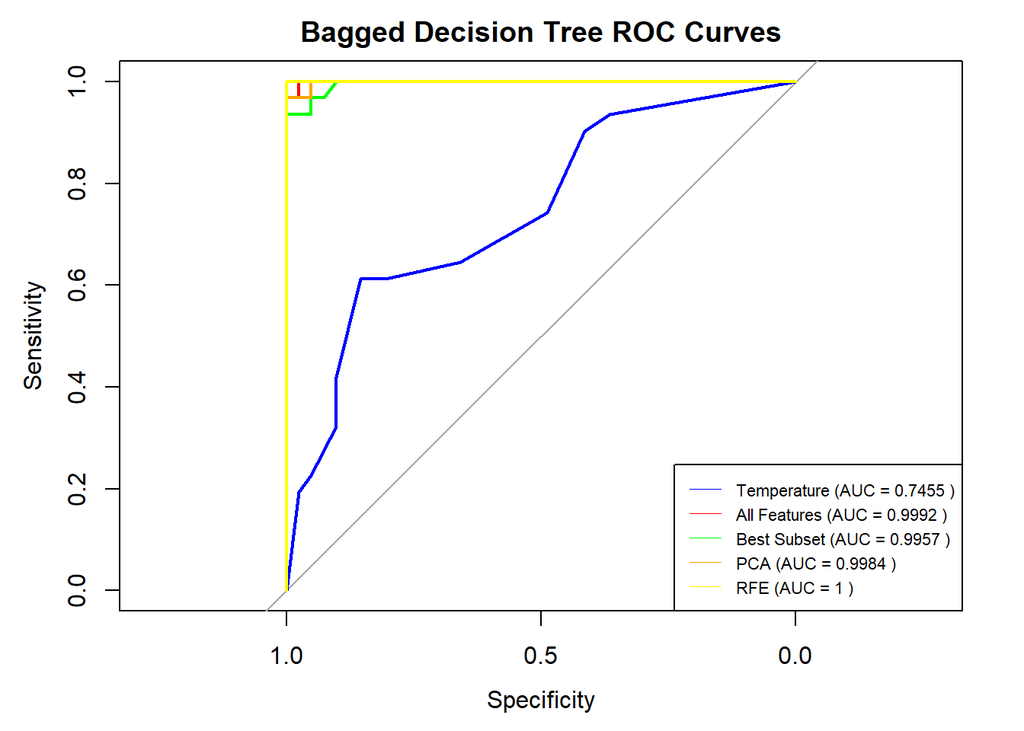

```r
plot_grid(bag_plot)
```

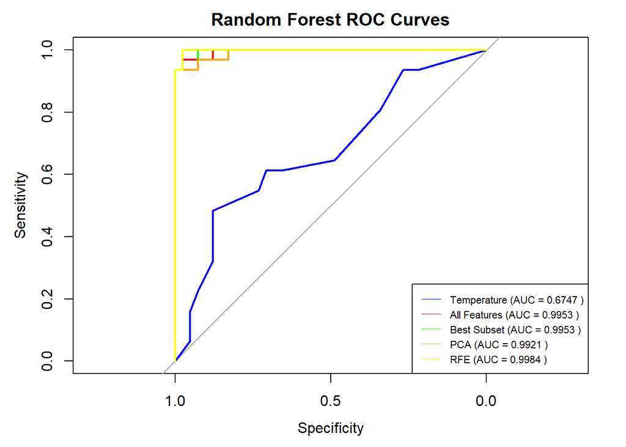

```r
plot_grid(rf_plot)
```

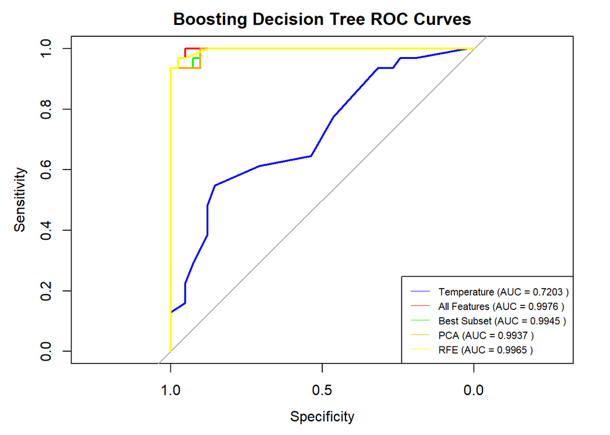

```r
plot_grid(boost_plot)
```

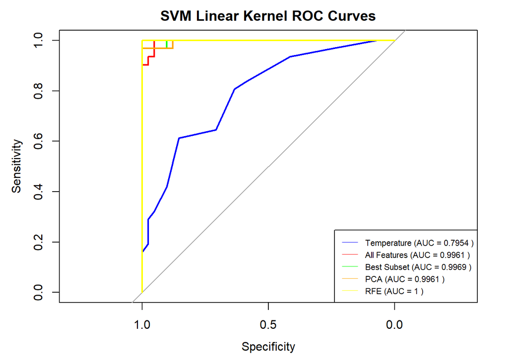

```r
plot_grid(svm_lin)
```

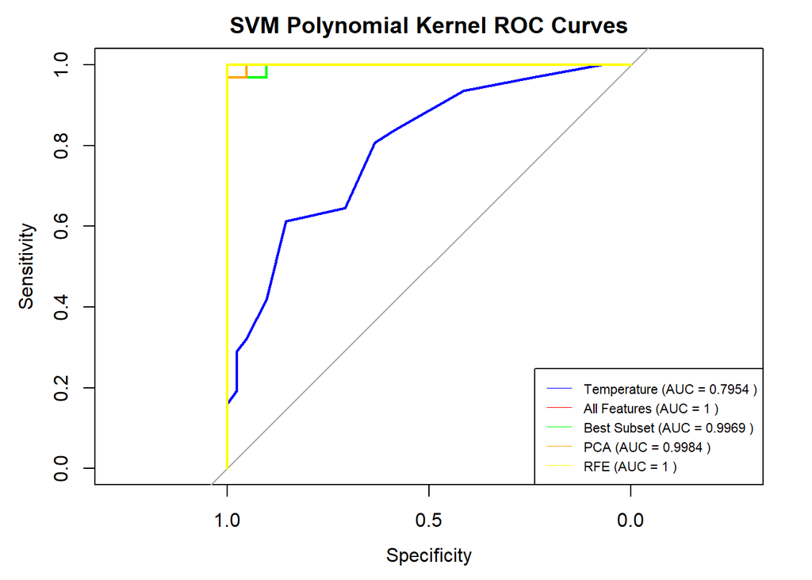

```r
plot_grid(svm_poly)
```

A few things are visually clear when comparing all of these figures together:

- The strongest subset was generally the one generated by RFE

  This is due to the nature of the dataset being highly separable / linearly separable. Random Forest was used as the method of evaluation in RFE. Because Random Forest is ultimately a decision tree method, it was able to divide the dataset based on the predictors given in a way that separated the classes almost perfectly. Additionally, when studying ISI and FFMC together, it is made very clear how separable the two are. This made it easy for every model to pick up on the separability and hone in on it.
- The maximum AUC for each model is very high

  This is likely due to the simplicity of the model. Once again the nature of the dataset is highly simplistic and so any of the given models should not have a hard time finding an optimal solution. Additionally, there are few data points which probably added to the simplicity. This is especially true when you take into account that all the values were gathered around summer in the span of three months. The set of values most likely present a local view of the true nature rather than a global one.
- The model that seems to have performed the worst is KNN

  KNN is a nonlinear method. It can be highly flexible when k is small and less so when large. However, due to the size of the dataset, taking a value of k around 100 is already pushing it. As k approaches the number of elements in the dataset, the grouping becomes dependent on which class is larger. Additionally, the nature of the data was highly simplistic and did not call for such a flexible/nonlinear model.

A dataframe containing all of these AUCs can be studied to get a further picture of these results.

```r
auc.data
```

```
##                     Model Temperature Entire_Dataset Best_Subset       PCA
## 1     Logistic Regression   0.7954367      1.0000000   0.9976397 1.0000000
## 2                     LDA   0.7954367      0.9889851   0.9913454 0.9866247
## 3                     QDA   0.7954367      0.9984264   0.9992132 0.9944925
## 4                     KNN   0.7966168      0.8922109   0.9712825 0.9803304
## 5           Decision Tree   0.6809599      0.9677419   0.9677419 0.9677419
## 6    Bagged Decision Tree   0.7454760      0.9992132   0.9956727 0.9984264
## 7           Random Forest   0.6746656      0.9952793   0.9952793 0.9921322
## 8   boosted decision tree   0.7202990      0.9976397   0.9944925 0.9937057
## 9     SVM (Linear Kernel)   0.7954367      0.9960661   0.9968529 0.9960661
## 10 SVM (Quadratic Kernel)   0.7954367      1.0000000   0.9968529 0.9984264
##          RFE
## 1  1.0000000
## 2  1.0000000
## 3  1.0000000
## 4  0.9972463
## 5  0.9677419
## 6  1.0000000
## 7  0.9984264
## 8  0.9964595
## 9  1.0000000
## 10 1.0000000
```

- In the case where Temperature was used as a lone predictor, KNN actually performed the best. It is possible that in this lone case, the flexibility of the method was able to pick up on certain intricacies. However, seeing as the AUC is not all that much greater than some of the other models’, this can also likely be attributed to a fluke favoring the KNN algorithm.
- When considering the entire dataset, the two models which performed the best were Logistic Regression and SVM with a quadratic kernel. It is highly understandable why logistic regression might perform so well on this dataset, but potentially less so when considering quadratic SVM. One possible explanation is that the predictors exhibiting nonlinear characteristics were taken advantage of more in the latter model and therefore the high AUC was contrived in a different way.

The AUCs of each model can be plotted in a bar graph as shown.

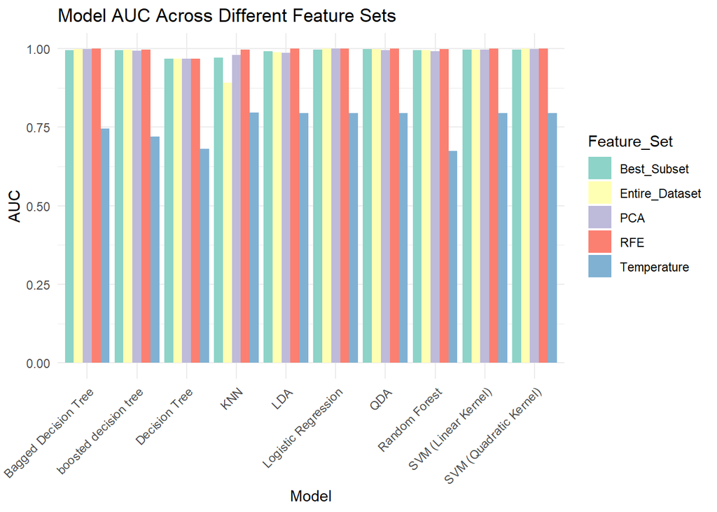

```r
auc.data[, -1] <- sapply(auc.data[, -1], as.numeric)

df_long = pivot_longer(auc.data, cols = -Model, names_to = "Feature_Set", values_to = "AUC")

ggplot(df_long, aes(x = Model, y = AUC, fill = Feature_Set)) +
  geom_bar(stat = "identity", position = "dodge") +
  theme_minimal() +
  labs(title = "Model AUC Across Different Feature Sets",
       x = "Model",
       y = "AUC") +
  theme(axis.text.x = element_text(angle = 45, hjust = 1)) +
  scale_fill_brewer(palette = "Set3")
```

Otherwise, the only other thing that this plot shows is the fact that every model performed exceedingly well.

# Conclusion

Through this project, several machine learning models were used to predict forest fires. The performance of each of these models was measured and interpreted based on key metrics such as accuracy, AUC, and ROC curves. All of the methods used produced strong predictive results. This was due to many factors including the simplicity of the model, the linear separability, and limited data points. There was a slight trend that indicated that more flexible models tended to overfit the data more and thus perform slightly worse. But even KNN, being one of the most nonlinear models of the bunch, performed better than well. Aside from the models, this project also highlights the importance of feature selection, preprocessing, and model tuning in achieving high predictive accuracy and gaining a greater understanding of the data at hand. The results underscore the potential of machine learning in environmental risk prediction, and offer potential for similar critical studies in related fields.